# HW5

Claire Wang

2021/3/28

## 【Question 1】

Some years ago, a Google engineer explained how they spot malicious apps (malware) that made it to their Android mobile apps store. Some malware apps deliberately turn off a security feature called Verify as soon as they are installed on an Android device. But there are also other, non-malicious, reasons why Verify might get turned off. So Google computes a “DOI score” for each app. The distribution of DOI scores is binomial, which Google approximates as a normal distribution (recall our reading on binomial distributions).

##### a. Given the critical DOI score that Google uses to detect malicious apps (-3.7), what is the probability that a randomly chosen app from Google’s app store will turn off the Verify security feature? (report a precise decimal fraction, not a percentage)

```r
pnorm(-3.7)
```

```
## [1] 0.0001077997
```

##### b. Assuming there were ~2.2 million apps when the article was written, what number of apps on the Play Store did Google expect would maliciously turn off the Verify feature once installed?

```r
sprintf("%f apps would maliciously turn off the Verify feature",round(2200000*pnorm(-3.7)))
```

```
## [1] "237.000000 apps would maliciously turn off the Verify feature"
```

## 【Question 2】

The large American phone company Verizon has a monopoly on phone services in many areas of the US. The New York Public Utilities Commission (PUC) regularly monitors repair times with customers in New York to verify the quality of Verizon’s services. Verizon claims that they take 7.6 minutes to repair phone services for its customers on average. The file verizon.csv has a recent sample of repair times collected by PUC, who seeks to verify this claim at 99% confidence.

```r
# Load data
verizon <- read.csv("verizon.csv",header = TRUE)
Ver_time <- verizon$Time
```

#### a) The Null distribution of t-values:

##### i. Visualize the distribution of Verizon’s repair times, marking the mean with a vertical line

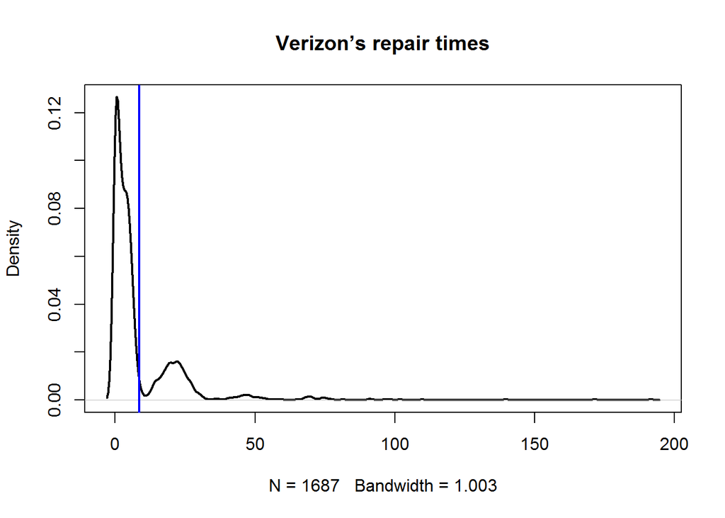

```r
plot(density(Ver_time),main="Verizon’s repair times", lwd=2)
abline(v=mean(Ver_time), col=rgb(0,0,1), lwd=2)
```

##### ii. Given what PUC wishes to test, how would you write the hypothesis? (not graded)

```r
# H0: average of repairing time = 7.6 minutes
# H1: average of repairing time != 7.6 minutes
```

##### iii. Estimate the population mean, and the 99% confidence interval (CI) of this estimate

```r
Ver_mean <- mean(Ver_time)
Ver_sd <- sd(Ver_time)
```

```r
sprintf("Population mean = %f", Ver_mean)
```

```
## [1] "Population mean = 8.522009"
```

```r
CI_min <- Ver_mean-3*Ver_sd
CI_max <- Ver_mean+3*Ver_sd
sprintf("99%% confidence interval = %f ~ %f ", CI_min, CI_max)
```

```
## [1] "99% confidence interval = -35.843443 ~ 52.887462 "
```

##### iv. Using the traditional statistical testing methods we saw in class, find the t-statistic and p-value of the test

```r
# t-statistic
t_stat <- (Ver_mean-7.6)/(Ver_sd/sqrt(length(Ver_time)))
sprintf(" t-statistic = %f ", t_stat)
```

```
## [1] " t-statistic = 2.560762 "
```

```r
#p-value
p_value <- 1-pt(t_stat,df=length(Ver_time)-1)
sprintf(" p-value = %f ", p_value)
```

```
## [1] " p-value = 0.005265 "
```

##### v. Briefly describe how these values relate to the Null distribution of t (not graded)

**Ans: We can get t=2.58 from t-table when probability is 0.99. And now we get t=2.56, which is in the range of CI.**

##### vi. What is your conclusion about the advertising claim from this t-statistic, and why?

**Ans: Although statistic t-value fall in the range of CI, it is close to the threshold(2.58). And consider the benchmark is 99%, I won’t say this advertise is very successful. Even so, it is okay.**

#### b) Let’s use bootstrapping on the sample data to examine this problem:

##### i. Bootstrapped Percentile: Estimate the bootstrapped 99% CI of the mean

```r
set.seed(1000)
boot_mean <- function(sample0){
  resample <- sample(sample0, length(sample0), replace = TRUE)
  return(mean(resample))
}
resampled_mean <- replicate(1000,boot_mean(Ver_time))
quantile(resampled_mean,c(0.005,0.995))
```

```
##     0.5%    99.5%
## 7.691881 9.513362
```

##### ii. Bootstrapped Difference of Means: What is the 99% CI of the bootstrapped difference between the population mean and the hypothesized mean?

```r
hypo_mean <- 7.6
boot_diff <- function(sample0,hypo_mean){
  resample <- sample(sample0, length(sample0), replace = TRUE)
  return(mean(resample)-hypo_mean)
}
resampled_diff <- replicate(1000,boot_diff(Ver_time,hypo_mean))
quantile(resampled_diff,c(0.005,0.995))
```

```
##        0.5%       99.5%
## 0.003719561 1.802901571
```

##### iii. Bootstrapped t-Interval: What is 99% CI of the bootstrapped t-statistic?

```r
boot_t <- function(sample0,hypo_mean){
  resample <- sample(sample0, length(sample0), replace = TRUE)
  t_stat <- (mean(resample)-hypo_mean)/(sd(resample)/sqrt(length(resample)))
  return(t_stat)
}
resampled_t <- replicate(1000,boot_t(Ver_time,hypo_mean))
quantile(resampled_t,c(0.005,0.995))
```

```
##        0.5%       99.5%
## -0.05949336  4.53115095
```

##### iv. Plot separate distributions of all three bootstraps above (for ii and iii make sure to include zero on the x-axis)

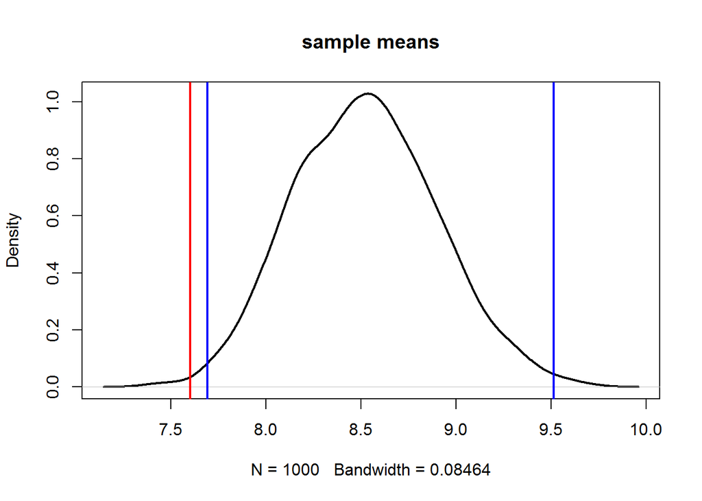

```r
# Bootstraps (i)Mean
plot(density(resampled_mean),main="sample means",lwd=2)
abline(v=unname(quantile(resampled_mean,c(0.005,0.995))),col=rgb(0,0,1),lwd=2)
abline(v=hypo_mean,col=rgb(1,0,0),lwd=2)
```

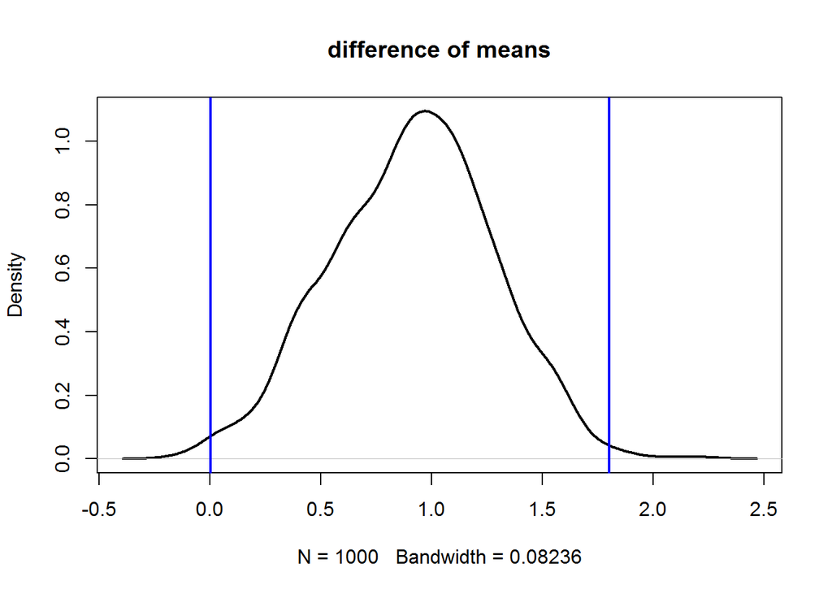

```r
# Bootstraps (ii)Difference of Means
plot(density(resampled_diff),main="difference of means",lwd=2)
abline(v=unname(quantile(resampled_diff,c(0.005,0.995))),col=rgb(0,0,1),lwd=2)
```

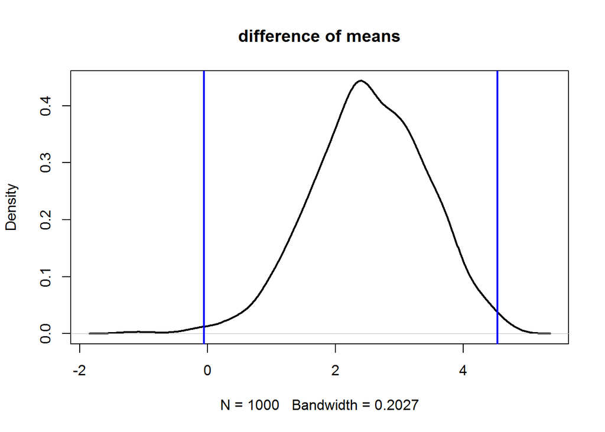

```r
# Bootsraps (iii)t-statistic
plot(density(resampled_t),main="difference of means",lwd=2)
abline(v=unname(quantile(resampled_t,c(0.005,0.995))),col=rgb(0,0,1),lwd=2)
```